# Chapter 4

Drivers of inequalities in access to planned hospital care

Steven Wyatt, The Strategy Unit

12 March 2021

### 2 Set-up and preparatory analysis

#### 2.1 Set-up

##### 2.1.1 Load required R packages

Set working directory.

Packages: tidyverse, scales

```r
setwd('Z:/Strategic Analytics/Projects 2020/753 Ineq Planned Care/panelAnalysis/r - IneqPlannedCare/r - IneqPlannedCare')

library(tidyverse)
library(scales)
library(broom)
```

##### 2.1.2 Read in data sets

The first file contains a count of elective inpatient spells by - year (2003 to 2018) - ICD10 Chapter - admission method (waiting lists, booked, planned) - deprivation decile, - provider sector (NHS / independent) and - time in weeks from decision to admit.  
Missing values of the variable indicating time from decision to admission, were imputed using the mean duration by year, provider, sector, admission methods, ICD10 Chapter and deprivation decile, where these variables were available.

The second file contains a count of six types of elective procedure: colonography, SPECT, AAA graft, bowel scope, carpal tunnel release and tonsilectomy. Counts and populations are provided by; - year (2003 to 2018) - procedure - STP and CCG *- index of multiple deprivation decile (IMD2019)* - single year of age (0-89, 90+) - sex

- derived from patient’s LSOA of residence

These files was created from record-level pseudonymised extracts from Hospital Episode Statistics, supplied by NHS Digital (DARS-NIC-05206-L1V6D-v4.6), using Transact SQL. The TSQL scripts can be provided on request.

The third file contains the european standard population by five year age groups (0, 1-4, 5-9 ….. 85-89, 90+). See https://ec.europa.eu/eurostat/documents/3859598/5926869/KS-RA-13-028-EN.PDF/e713fa79-1add-44e8-b23d-5e8fa09b3f8f

```r
IneqSecCareElecDur_wkg <- readRDS(file = 'IneqSecCareElecDur_wkg.RDS')

IneqSecCareDsrSpecificProcsInput <- readRDS(file = 'IneqSecCareDsrSpecificProcsInput.RDS')


# set up european standard population ------
esr <- data.frame(ageGrp = rep(c('00', '01-04', '05-09', '10-14', '15-19', '20-24', '25-29', '30-34', '35-39', '40-44',
                                  '45-49', '50-54', '55-59', '60-64', '65-69', '70-74', '75-79', '80-84', '85-89', '90plus'), 2),
                  sex = c(rep(1, 20), rep(2, 20)),
                  sPop = rep(c(1000, 4000, 5500, 5500, 5500, 6000, 6000, 6500, 7000, 7000,
                               7000, 7000, 6500, 6000, 5500, 5000, 4000, 2500, 1500, 1000), 2))
```

#### 2.2 Wrangle data

```r
IneqSecCareDsrSpecificProcsInput_wkg <- IneqSecCareDsrSpecificProcsInput %>%
  filter(yr >= 2005 & yr <= 2018) %>%
  mutate(ageGrp = case_when(age == 0 ~ '00',
                            age <= 4 ~ '01-04',
                            age <= 10 ~ '05-09',
                            age <= 14 ~ '10-14',
                            age <= 19 ~ '15-19',
                            age <= 24 ~ '20-24',
                            age <= 29 ~ '25-29',
                            age <= 34 ~ '30-34',
                            age <= 39 ~ '35-39',
                            age <= 44 ~ '40-44',
                            age <= 49 ~ '45-49',
                            age <= 54 ~ '50-54',
                            age <= 59 ~ '55-59',
                            age <= 64 ~ '60-64',
                            age <= 69 ~ '65-69',
                            age <= 74 ~ '70-74',
                            age <= 79 ~ '75-79',
                            age <= 84 ~ '80-84',
                            age <= 89 ~ '85-89',
                            age == 90 ~ '90plus',
                            TRUE ~ 'check')) %>%
  group_by(yr, STP20CD, CCG20CD, CCG20CDH, imd2019Dec, ageGrp, sex) %>%
  summarise(tonsilectomy = sum(tonsilectomy),
            grommets = sum(grommets),
            carpalTunnelRelease = sum(carpalTunnelRelease),
            spect = sum(spect),
            colonography = sum(colonogrpahy),
            pop = sum(pop)) %>%
  pivot_longer(cols = 8:12,
               names_to = 'procType',
               values_to = 'act') %>%
  bind_rows(IneqSecCareDsrSpecificProcsInput %>%
    filter(yr >= 2005 & yr <= 2018) %>%
    filter(age == 55) %>%
    mutate(ageGrp = '55') %>%
    mutate(procType = 'bowelScope55') %>%
    group_by(yr, STP20CD, CCG20CD, CCG20CDH, imd2019Dec, ageGrp, sex, procType) %>%
    summarise(act = sum(bowelScope55),
              pop = sum(pop))) %>%
  bind_rows(IneqSecCareDsrSpecificProcsInput %>%
              filter(yr >= 2005 & yr <= 2018) %>%
              filter(sex == 1) %>%
              filter(age == 65) %>%
              mutate(ageGrp = '65') %>%
              mutate(procType = 'aaaGraft65m') %>%
              group_by(yr, STP20CD, CCG20CD, CCG20CDH, imd2019Dec, ageGrp, sex, procType) %>%
              summarise(act = sum(aaaGraft65m),
                        pop = sum(pop)))
```

#### 2.3 Calculate activity rates

Calculate crude and directly age standardized rates and 95% confidence intervals for six procedures: colonography, SPECT, AAA graft, bowel scope, carpal tunnel release and tonsilectomy.

Byars method is used to calculate confidence intervals for directly standardised rates.

```r
#Specific Procs Crude rates IMDQ year --------
specificProcsCrudeRatesImdYear <- IneqSecCareDsrSpecificProcsInput_wkg %>%
  mutate(imdQ = ceiling(as.numeric(imd2019Dec)/2)) %>%
  group_by(yr, imdQ , procType) %>%
  summarise(act = sum(act),
            rate = sum(act) / sum (pop),
            lcl95 = qpois(.025, sum(act)) / sum (pop),
            ucl95 = qpois(.975, sum(act)) / sum (pop),
            pop = sum(pop))




#Specific Procs DSR IMDQ year --------
specificProcsDsRatesImdYear <- IneqSecCareDsrSpecificProcsInput_wkg %>%
  filter(procType != 'bowelScope55') %>%
  filter(procType != 'aaaGraft65m') %>%
  mutate(imdQ = ceiling(as.numeric(imd2019Dec)/2)) %>%
  group_by(yr, imdQ, procType, sex, ageGrp) %>%
  summarise(act = sum(act),
            pop = sum(pop)) %>%
  left_join(esr, by = c('sex', 'ageGrp')) %>%
  mutate(w1 = sPop * act / pop,
         w2 = (sPop^2) * act / (pop^2)) %>%
  group_by(yr, imdQ, procType) %>%
  summarise(sumW1 = sum(w1),
            sumW2 = sum(w2),
            sumAct = sum(act),
            sumPop = sum(pop),
            sumSPop = sum(sPop)) %>%
  mutate(rate = sumW1 / sumSPop,
         lcl95 = (sumW1 / sumSPop) + ((sumW2/sumSPop^2/sumAct)^0.5) * (sumAct*((1 - 1/(9*sumAct)) + qnorm(0.025, mean = 0, sd = 1)/3/sumAct^0.5)^3 - sumAct),
         ucl95 = (sumW1 / sumSPop) + ((sumW2/sumSPop^2/sumAct)^0.5) * ((sumAct+1)*((1 - 1/(9*(sumAct+1))) - qnorm(0.025, mean = 0, sd = 1)/3/(sumAct+1)^0.5)^3 - sumAct)) %>%
  select(-sumAct, -sumW1, -sumW2, -sumSPop, pop = sumPop)    %>%
  bind_rows(specificProcsCrudeRatesImdYear %>%
              filter(procType == 'bowelScope55' | procType == 'aaaGraft65m'))


specificProcsRatesImdYear <- specificProcsCrudeRatesImdYear %>%
  mutate(rateType = 'crude') %>%
  bind_rows(specificProcsDsRatesImdYear %>%
              mutate(rateType = 'dsr'))

saveRDS(specificProcsRatesImdYear, file = 'specificProcsRatesImdYear.RDS')
```

#### 3.1 Elective waiting times by year and deprivation

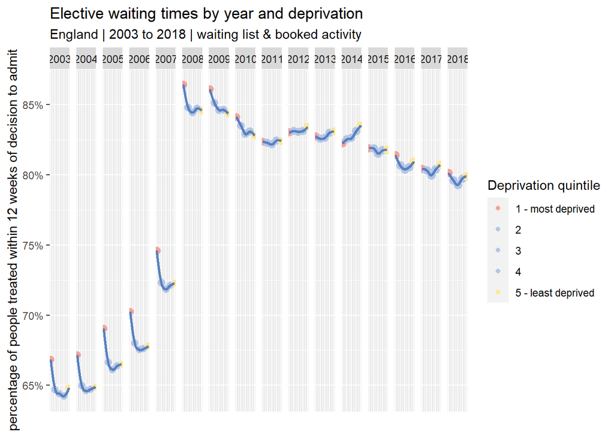

```r
IneqSecCareElecDur_wkg %>%
  mutate(imdQ = case_when(imdDec %in% c('1', '2') ~ 1,
                          imdDec %in% c('3', '4') ~ 2,
                          imdDec %in% c('5', '6') ~ 3,
                          imdDec %in% c('7', '8') ~ 4,
                          imdDec %in% c('9', '10') ~ 5,
                          TRUE ~ NA_real_)) %>%
  #filter(icd10Chapter == 'I') %>%
  filter(admimeth != '13') %>%
  mutate(elecDurLess12Wk = ifelse(elecDurWk < 12, 1, 0)) %>%
  group_by(imdQ, yr) %>%
  mutate(imdSpells = sum(spells, na.rm = TRUE)) %>%
  group_by(imdQ, yr, elecDurLess12Wk) %>%
  summarise(spells = sum(spells, na.rm = TRUE),
            pSpells = sum(spells, na.rm = TRUE) / max(imdSpells),
            imdSpells = max(imdSpells)) %>%
  filter(elecDurLess12Wk == 1) %>%
  filter(!is.na(imdQ)) %>%
  ggplot() +
  geom_point(aes(x = imdQ, y = pSpells, size = imdSpells, colour = as.factor(imdQ))) +
  geom_smooth(aes(x = imdQ, y = pSpells),
              colour = '#5881c1',
              method = 'loess',
              formula = 'y ~ x',
              span = 0.9) +
  scale_y_continuous(name = 'percentage of people treated within 12 weeks of decision to admit',
                     limits = c(NA_real_, NA_real_),
                     labels = percent_format(accuracy = 1)) +
  scale_x_continuous(name = '') +
  scale_size_area(max_size = 3, guide = FALSE) +
  scale_colour_manual(name = 'Deprivation quintile',
                      values = c('#f4a39a', '#b4c6e6', '#b4c6e6', '#b4c6e6', '#ffe699'),
                      labels = c('1 - most deprived', '2', '3', '4', '5 - least deprived')) +
  facet_grid(cols = vars(yr)) +
  labs(title = 'Elective waiting times by year and deprivation',
       subtitle = 'England | 2003 to 2018 | waiting list & booked activity') +
  theme(axis.text.x = element_blank(),
        axis.ticks.x = element_blank())
```

In the early and mid-2000s, people in more deprived areas were, on average, getting faster access to elective inpatient activity. Waiting times improved dramatically for all groups in the late 2000s. By 2014 the gradient in waiting times across deprivation quintiles had reversed, and those in less deprived areas were receiving faster access to care. Since 2014, waiting times have deteriorated and the gradient across deprivation quintiles has become less clear.

#### 3.2 Elective spells in independent sector provision by year and deprivation

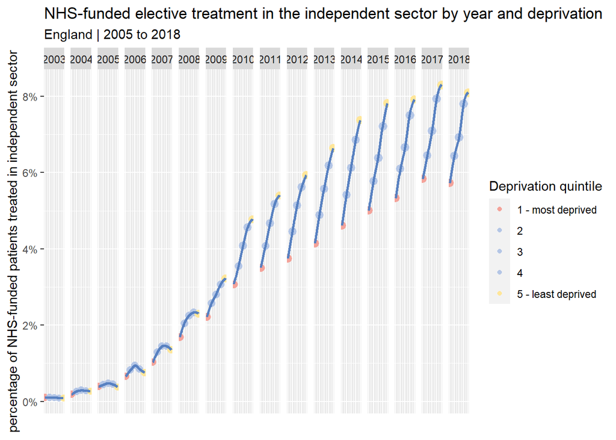

```r
IneqSecCareElecDur_wkg %>%
  mutate(imdQ = case_when(imdDec %in% c('1', '2') ~ 1,
                          imdDec %in% c('3', '4') ~ 2,
                          imdDec %in% c('5', '6') ~ 3,
                          imdDec %in% c('7', '8') ~ 4,
                          imdDec %in% c('9', '10') ~ 5,
                          TRUE ~ NA_real_)) %>%
  #filter(icd10Chapter == 'M') %>%
  group_by(imdQ, yr) %>%
  mutate(imdSpells = sum(spells, na.rm = TRUE)) %>%
  group_by(imdQ, yr, nhsProv) %>%
  summarise(spells = sum(spells, na.rm = TRUE),
            pSpells = sum(spells, na.rm = TRUE) / max(imdSpells),
            imdSpells = max(imdSpells)) %>%
  filter(nhsProv == 0) %>%
  filter(!is.na(imdQ)) %>%
  ggplot() +
  geom_point(aes(x = imdQ, y = pSpells, size = imdSpells, colour = as.factor(imdQ))) +
  geom_smooth(aes(x = imdQ, y = pSpells),
              colour = '#5881c1',
              method = 'loess',
              formula = 'y ~ x',
              span = 0.9) +
  scale_y_continuous(name = 'percentage of NHS-funded patients treated in independent sector',
                     limits = c(NA_real_, NA_real_),
                     labels = percent_format(accuracy = 1)) +
  scale_x_continuous(name = '') +
  scale_size_area(max_size = 3, guide = FALSE) +
  scale_colour_manual(name = 'Deprivation quintile',
                      values = c('#f4a39a', '#b4c6e6', '#b4c6e6', '#b4c6e6', '#ffe699'),
                      labels = c('1 - most deprived', '2', '3', '4', '5 - least deprived')) +
  facet_grid(cols = vars(yr)) +
  labs(title = 'NHS-funded elective treatment in the independent sector by year and deprivation',
       subtitle = 'England | 2005 to 2018') +
  theme(axis.text.x = element_blank(),
        axis.ticks.x = element_blank())
```

In the early 2000s, NHS-funded access to the independent sector was negligible. The development of ISTCs in the mid-2000s and the extended choice policy initiative in 2007 resulted in a steady increase in NHS-funded independent sector activity. Access to independent sector providers is substantially higher among the least deprived populations and the disparity is increasing.

#### 3.3 New diagnostic procedures

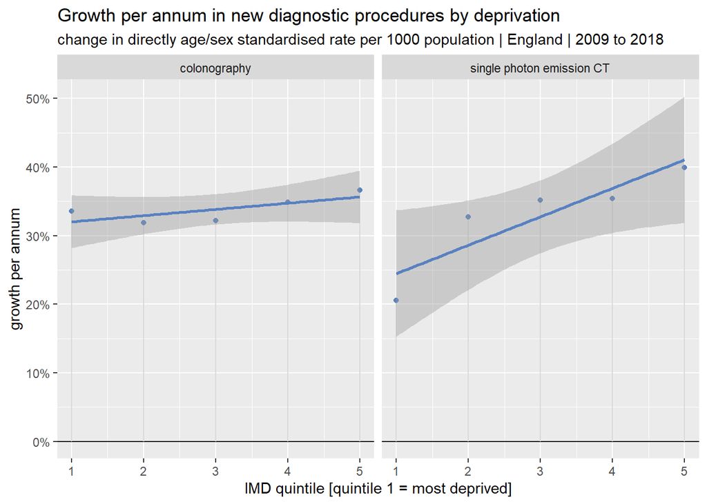

```r
##change in dsr rates by procedure and IMD 2009 ro 2018 ------


resDf <- data.frame(procType = character(),
                    imdQ = numeric(),
                    growthPa = numeric())


for (i in c('grommets', 'tonsilectomy', 'carpalTunnelRelease',
            'bowelScope55', 'colonography', 'spect', 'aaaGraft65m'))
{
  yrStart <- 2009

  for (j in seq(1, 5, 1))
  {
    lmDf <- specificProcsRatesImdYear %>%
        filter(rateType == 'dsr') %>%
        select(-act) %>%
        filter(yr >= yrStart) %>%
        mutate(logRate = log(rate)) %>%
        filter(imdQ == j, procType == i)

    lm <- lm(logRate ~ yr, data = lmDf)

    resDf <- resDf %>%
      bind_rows(data.frame(procType = i,
                           imdQ = j,
                           growthPa = exp(tidy(lm)$estimate[2])))

  }

}


##change in new diagnostic procedures by IMD 2009 ro 2018 ------
resDf %>%
  filter(procType == 'colonography' | procType == 'spect') %>%
  mutate(procTypeLabel = ifelse(procType == 'spect', 'single photon emission CT', 'colonography')) %>%
  mutate(growthPa = growthPa - 1) %>%
  ggplot() +
  geom_hline(aes(yintercept = 0)) +
  geom_segment(aes(x = imdQ, y = 0, xend = imdQ, yend = growthPa),
               colour = '#d9d9d9') +
  geom_point(aes(x = imdQ, y = growthPa), colour = '#5881c1') +

  geom_smooth(aes(x = imdQ, y = growthPa),
              method = 'lm',
              formula = 'y ~ x',
              colour = '#5881c1') +
  facet_grid(cols = vars(procTypeLabel)) +
  scale_y_continuous(name = 'growth per annum',
                     label = percent_format(accuracy = 1),
                     limits = c(0, NA_real_)) +
  scale_x_continuous(name = 'IMD quintile [quintile 1 = most deprived]') +
  labs(title = 'Growth per annum in new diagnostic procedures by deprivation',
       subtitle = 'change in directly age/sex standardised rate per 1000 population | England | 2009 to 2018')
```

Between 2009 and 2018, the growth in the use of colonography and SPECT has been greater for those living in the least deprived areas.

#### 3.4 Procedures of limited clinical value

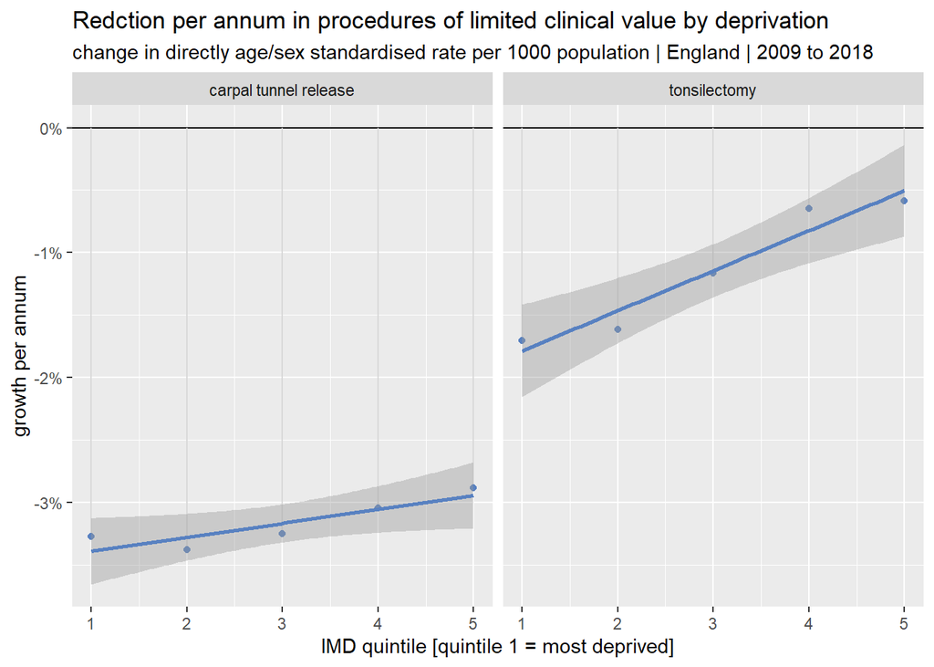

```r
##change in procedures of limited clinical value by   IMD 2009 ro 2018 ------
resDf %>%
  filter(procType == 'carpalTunnelRelease' | procType == 'tonsilectomy') %>%
  mutate(procTypeLabel = ifelse(procType == 'carpalTunnelRelease', 'carpal tunnel release', 'tonsilectomy')) %>%
  mutate(growthPa = growthPa - 1) %>%
  ggplot() +
  geom_hline(aes(yintercept = 0)) +
  geom_segment(aes(x = imdQ, y = 0, xend = imdQ, yend = growthPa),
               colour = '#d9d9d9') +
  geom_point(aes(x = imdQ, y = growthPa), colour = '#5881c1') +
  geom_smooth(aes(x = imdQ, y = growthPa),
              method = 'lm',
              formula = 'y ~ x',
              colour = '#5881c1') +
  facet_grid(cols = vars(procTypeLabel)) +
  scale_y_continuous(name = 'growth per annum',
                     label = percent_format(accuracy = 1),
                     limits = c(NA_real_, 0)) +
  scale_x_continuous(name = 'IMD quintile [quintile 1 = most deprived]') +
  labs(title = 'Redction per annum in procedures of limited clinical value by deprivation',
       subtitle = 'change in directly age/sex standardised rate per 1000 population | England | 2009 to 2018')
```

#### 3.5 Procedures following new screening programmes

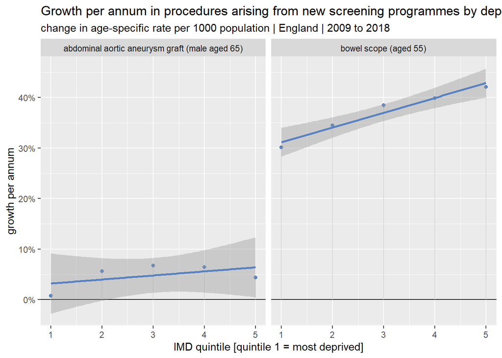

```r
##change in procedures following new screening programme by IMD 2009 ro 2018 ------
resDf %>%
  filter(procType == 'bowelScope55' | procType == 'aaaGraft65m') %>%
  mutate(procTypeLabel = ifelse(procType == 'bowelScope55', 'bowel scope (aged 55)', 'abdominal aortic aneurysm graft (male aged 65)')) %>%
  mutate(growthPa = growthPa - 1) %>%
  ggplot() +
  geom_hline(aes(yintercept = 0)) +
  geom_segment(aes(x = imdQ, y = 0, xend = imdQ, yend = growthPa),
               colour = '#d9d9d9') +
  geom_point(aes(x = imdQ, y = growthPa), colour = '#5881c1') +
  geom_smooth(aes(x = imdQ, y = growthPa),
              method = 'lm',
              formula = 'y ~ x',
              colour = '#5881c1') +
  facet_grid(cols = vars(procTypeLabel)) +
  scale_y_continuous(name = 'growth per annum',
                     label = percent_format(accuracy = 1),
                     limits = c(NA_real_, NA_real_)) +
  scale_x_continuous(name = 'IMD quintile [quintile 1 = most deprived]') +
  labs(title = 'Growth per annum in procedures arising from new screening programmes by deprivation',
       subtitle = 'change in age-specific rate per 1000 population | England | 2009 to 2018')
```